# PROGRAMACIÓN Y DATA SCIENCE CON R - INTERMEDIO

Nestor Montaño  
Noviembre.2017

Vicerrectorado de Formación Académica y Profesional  
Universidad de Guayaquil

## Análisis exploratorio de datos

### R - cargar librerías

```r
library(openxlsx)
library(dplyr)
library(tidyr)
library(magrittr)
library(readr)
library(ggplot2)
library(hexbin)
library(lubridate)
```

### Importar data

```r
# Cargar la libreria a utilizar
library(openxlsx)
# Leer el archivo de excel y asignarlo al objeto data_banco
data_banco <- read.xlsx(xlsxFile = "Data/Data_Banco.xlsx", sheet = "Data")
data_sucursal <- read.xlsx(xlsxFile = "Data/Data_Banco.xlsx", sheet = "Data_Sucursal")
```

### Convertir a tibbles (un dataframe mejorado):

```r
# Convertir el data_banco a un tibble
data_banco <- tbl_df( data_banco)
# Convertir el data_sucursal a un tibble
data_sucursal <- tbl_df(data_sucursal)
```

### Manipulacion de datos - Tipos de datos

Lo primero que necesitamos es corregir los tipos de datos.

```r
data_banco <- data_banco %>%
  mutate(Sucursal= parse_character(Sucursal),
         Cajero = parse_character(Cajero),
         Satisfaccion = parse_factor(Satisfaccion, levels= c('Muy Malo', 'Malo', 'Regular', 'Bueno', 'Muy Bueno'))
         )

data_sucursal <- data_sucursal %>%
  mutate(ID_Sucursal= parse_character(ID_Sucursal))
```

### Manipulacion de datos - Join

Cambiamos el nombre de la Sucursar en el data_banco y hacemos join on data_sucursal, reemplazando el data_banco original.

```r
data_banco <- data_banco %>%
  rename("ID_Sucursal"="Sucursal") %>%
  left_join(data_sucursal, by= c("ID_Sucursal"))
```

### Data Banco

```r
data_banco
```

```
# A tibble: 24,299 x 9
   ID_Sucursal Cajero ID_Transaccion              Transaccion
         <chr>  <chr>          <dbl>                    <chr>
 1          62   4820              2 Cobro/Pago (Cta externa)
 2          62   4820              2 Cobro/Pago (Cta externa)
 3          62   4820              2 Cobro/Pago (Cta externa)
 4          62   4820              2 Cobro/Pago (Cta externa)
 5          62   4820              2 Cobro/Pago (Cta externa)
 6          62   4820              2 Cobro/Pago (Cta externa)
 7          62   4820              2 Cobro/Pago (Cta externa)
 8          62   4820              2 Cobro/Pago (Cta externa)
 9          62   4820              2 Cobro/Pago (Cta externa)
10          62   4820              2 Cobro/Pago (Cta externa)
# ... with 24,289 more rows, and 5 more variables:
#   Tiempo_Servicio_seg <dbl>, Satisfaccion <fctr>, Monto <dbl>,
#   Sucursal <chr>, Nuevo_Sistema <chr>
```

### ggplot2 - Componentes de un gráfico

- Datos junto con características estéticas
- Objetos geométricos, (puntos, líneas, polígonos, áreas, etc.)
- Transformaciones estadísticas
- Escalas
- Sistema de coordenadas
- Condicionamiento

### ggplot2 - Algunas geometrías disponibles

| Geom | Descripción | aes() |
| --- | --- | --- |
| `geom_histogram` | Histograma | `x` |
| `geom_bar` | Gráfico de barras | `x` |
| `geom_density` | Gráfico de densidad (histograma suavizado) | `x` |
| `geom_boxplot` | Boxplot | `x, y` |
| `geom_line` | Dibujar una línea ordenando los valores de x | `x, y` |
| `geom_path` | Dibujar una línea en el orden de aparición de x | `x, y` |
| `geom_point` | Gráfico de dispersión | `x, y` |

### ggplot2 - Algunas geometrías disponibles

| Geom | Descripción | aes() |
| --- | --- | --- |
| `geom_smooth` | Agrega un modelo y su intervalo de confianza | `x, y` |
| `geom_bin2d` | Dibuja rectángulos y pinta según cantidad de datos | `x, y` |
| `geom_ribbon` | Dibujar intervalos para cada valor de x | `ymin, ymax` |
| `geom_errorbar` | Barras de error | `ymin, ymax` |
| `geom_text` | Agregar texto al gráfico | `x, y, label` |
| `geom_label` | Agregar texto con rectángulo al gráfico | `x, y, label` |
| `geom_tile` | Permite crear rectángulos coloreados | `x, y, fill` |

### ggplot2

Para empezar un gráfico con ggplot se declara primero el objeto (data.frame) a utilizar y las estéticas que son requeridas por el gráfico. En este caso vamos a empezar con un histograma, por lo que (según la tabla anterior) debemos declarar “x”. *Nótese que se ha creado un layer con el Tiempo de Servicio en el eje x*

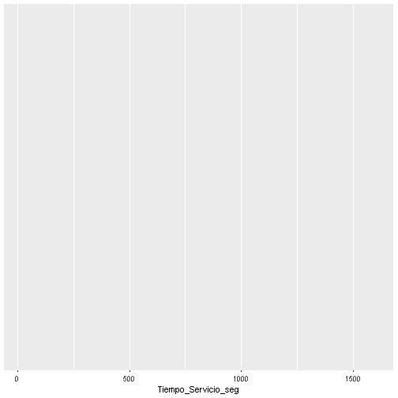

```r
# Datos junto con características estéticas
ggplot(data_banco, aes(x = Tiempo_Servicio_seg))
```

### ggplot2

Luego se declara el objeto geométrico principal

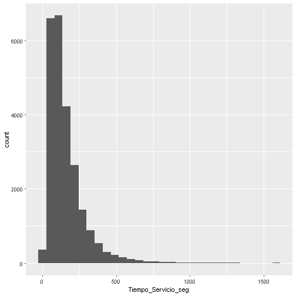

```r
ggplot(data_banco, aes(x = Tiempo_Servicio_seg)) + geom_histogram()
```

### ggplot2

El objeto geométrico puede tener sus propias características, el histograma por ejemplo permite graficar frecuencia relativa en lugar de frecuencia absoluta

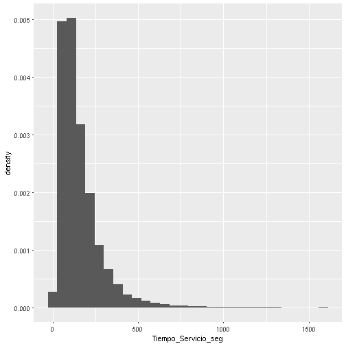

```r
ggplot(data_banco, aes(x = Tiempo_Servicio_seg)) +
  geom_histogram(aes(y = ..density..))
```

### ggplot2

Que es lo mismo que hace.

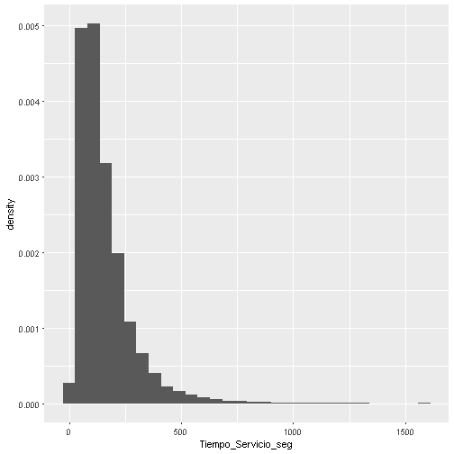

```r
ggplot(data_banco, aes(x = Tiempo_Servicio_seg, y = ..density..)) +
  geom_histogram()
```

### ggplot2

La potencia de ggplot es que podemos **mapear** otras variables a las características estéticas, por ejemplo, la sucursal al relleno (fill) de las barras

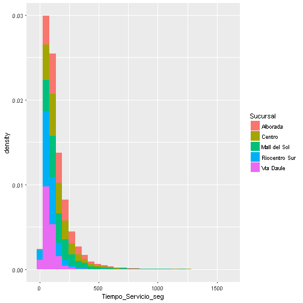

```r
ggplot(data_banco, aes(x = Tiempo_Servicio_seg, fill= Sucursal)) +
  geom_histogram(aes(y = ..density..), )
```

### ggplot2

Mapeando al eje y la densidad, al relleno la sucursal y definidiendo como opción del histograma “position= "fill”“

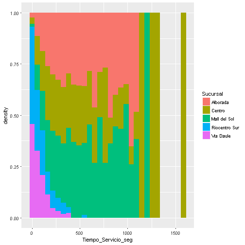

```r
ggplot(data_banco, aes(x = Tiempo_Servicio_seg, fill= Sucursal)) +
  geom_histogram(aes(y = ..density..), position = "fill")
```

### ggplot2

Cada geom en ggplot es un layer que se aumenta al gráfico, podemos entonces aumentar layers al gráfico.

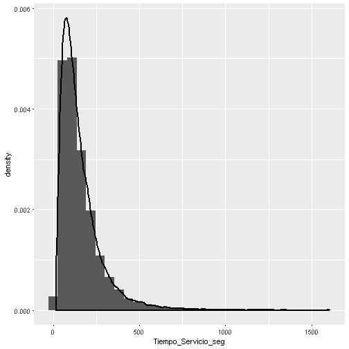

```r
ggplot(data_banco, aes(x = Tiempo_Servicio_seg)) +
  geom_histogram(aes(y = ..density..)) +
  geom_density(lwd=1)
```

### ggplot2

Histograma de frecuencia relativa + densidad + curva normal con la media y desviación de la muestra.

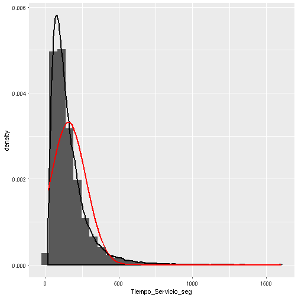

```r
ggplot(data_banco, aes(x = Tiempo_Servicio_seg)) +
  geom_histogram(aes(y = ..density..)) +
  geom_density(lwd=1) +
  stat_function(fun = dnorm, colour = "red", lwd=1,
                args = list(mean = mean(data_banco$Tiempo_Servicio_seg, na.rm = TRUE),
                            sd = sd(data_banco$Tiempo_Servicio_seg, na.rm = TRUE)))
```

### ggplot2

Nótese la diferencia de cuándo se usa fill= Sucursal, esa variable se mapea para ambos layers

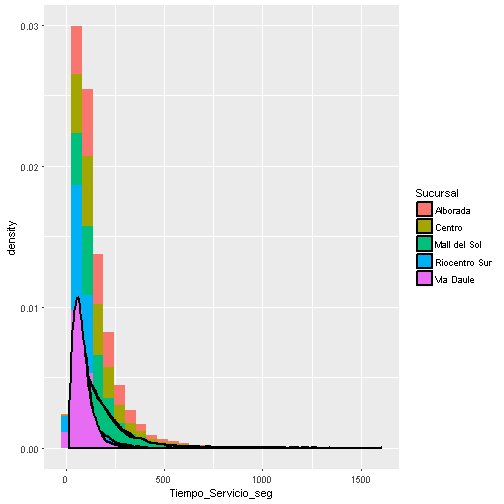

```r
ggplot(data_banco, aes(x = Tiempo_Servicio_seg, fill= Sucursal)) +
  geom_histogram(aes(y = ..density..)) +
  geom_density(lwd=1)
```

### ggplot2

Ahora se pone el fill sólo en geom_histogram, nótese la altura de la densidad

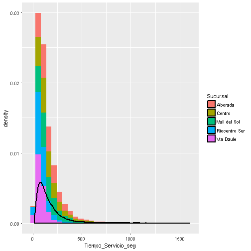

```r
ggplot(data_banco, aes(x = Tiempo_Servicio_seg)) +
  geom_histogram(aes(y = ..density.., fill= Sucursal)) +
  geom_density(lwd=1)
```

### ggplot2

Modificamos la estética **y** para poder aumentar la altura de la densidad (que ya no sería estríctamente densidad)

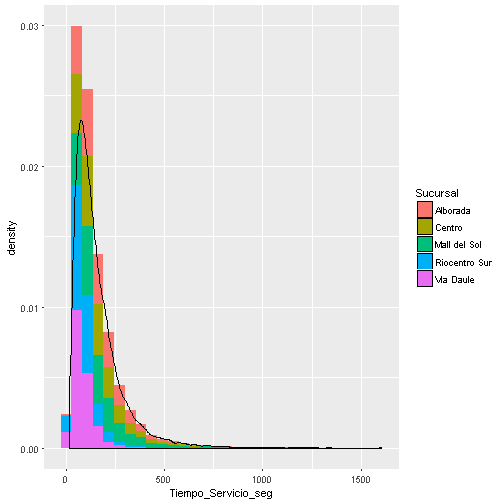

```r
ggplot(data_banco, aes(x = Tiempo_Servicio_seg)) +
  geom_histogram(aes(y = ..density.., fill= Sucursal)) +
  geom_density(aes(y= 4 * ..density..), lwd=0.5)
```

### ggplot2

Jugando con las opciones ya conocidas

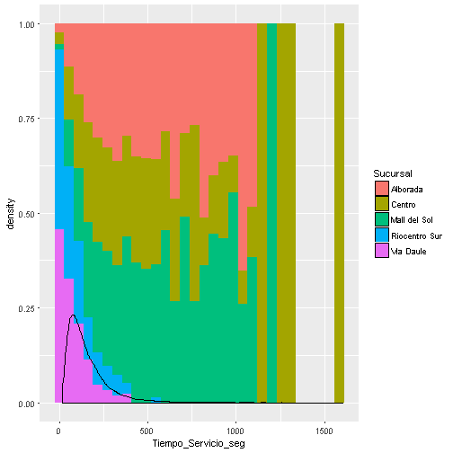

```r
ggplot(data_banco, aes(x = Tiempo_Servicio_seg)) +
  geom_histogram(aes(y = ..density.., fill= Sucursal),  position = "fill") +
  geom_density(aes(y= 40 * ..density..), lwd=0.5)
```

### ggplot2

Ahora vamos a comparar los histogramas del Tiempo de Servicio según la transacción

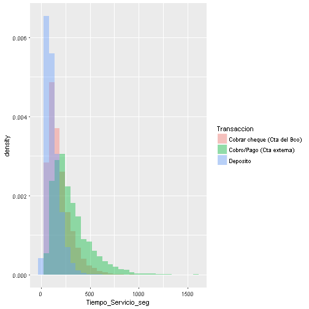

```r
ggplot(data_banco, aes(x = Tiempo_Servicio_seg)) +
  geom_histogram(aes(y = ..density.., fill= Transaccion),  position = "identity", alpha= 0.4)
```

### ggplot2

Nótese cómo varía el gráfico al variar el parámetro *position*

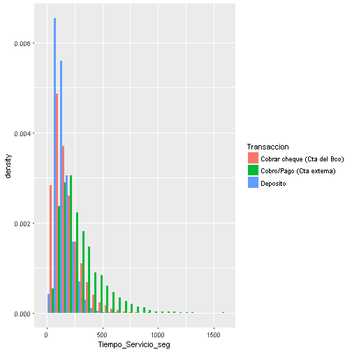

```r
ggplot(data_banco, aes(x = Tiempo_Servicio_seg)) +
  geom_histogram(aes(y = ..density.., fill= Transaccion),  position = "dodge")
```

### ggplot2

Agreguemos densidad primer intento

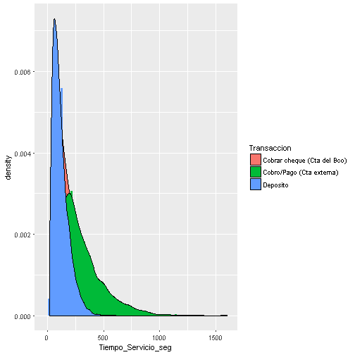

```r
ggplot(data_banco, aes(x = Tiempo_Servicio_seg, fill= Transaccion)) +
  geom_histogram(aes(y = ..density..),  position = "dodge") +
  geom_density(lwd=0.5)
```

### ggplot2

Usemos alpha en densidad

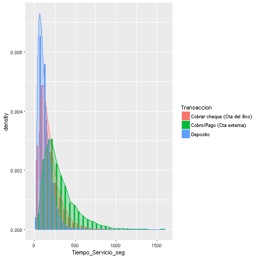

```r
ggplot(data_banco, aes(x = Tiempo_Servicio_seg, fill= Transaccion)) +
  geom_histogram(aes(y = ..density..),  position = "dodge") +
  geom_density(aes(color= Transaccion), lwd=0.5, alpha= 0.3)
```

### ggplot2

Juguemos con *fill* y *color*

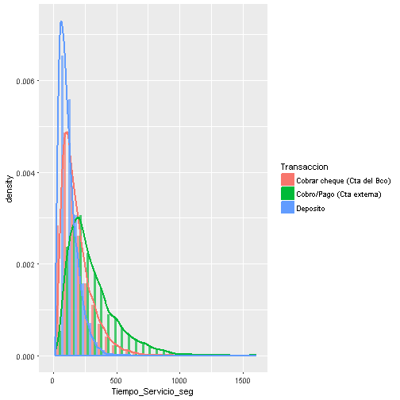

```r
ggplot(data_banco, aes(x = Tiempo_Servicio_seg)) +
  geom_histogram(aes(y = ..density.., fill= Transaccion),  position = "dodge", alpha= 0.7) +
  geom_density(aes(color= Transaccion), lwd=1 )
```

### ggplot2

Quizá mejor es tener los histogramas separados, usamos facet

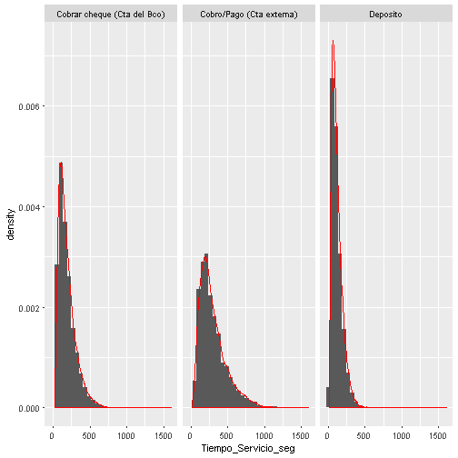

```r
ggplot(data_banco, aes(x = Tiempo_Servicio_seg)) +
  geom_histogram(aes(y = ..density..)) +
  geom_density(lwd=0.2, color= "red") +
  facet_grid(~Transaccion)
```

### ggplot2

Parámetro en facet

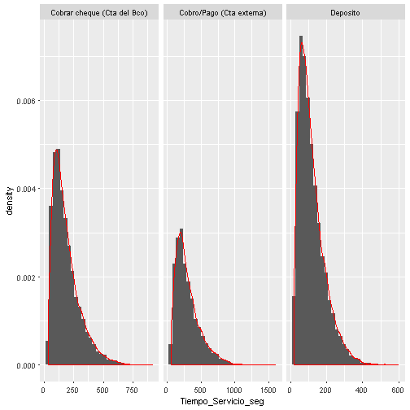

```r
ggplot(data_banco, aes(x = Tiempo_Servicio_seg)) +
  geom_histogram(aes(y = ..density..)) +
  geom_density(lwd=0.2, color= "red") +
  facet_grid(~Transaccion, scales = "free_x")
```

### ggplot2

De forma vertical

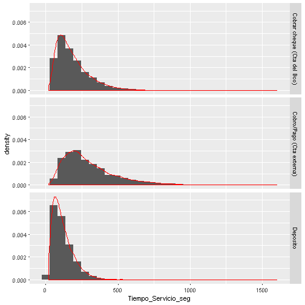

```r
ggplot(data_banco, aes(x = Tiempo_Servicio_seg)) +
  geom_histogram(aes(y = ..density..)) +
  geom_density(lwd=0.2, color= "red") +
  facet_grid(Transaccion~.)
```

### ggplot2

Parámetro en facet

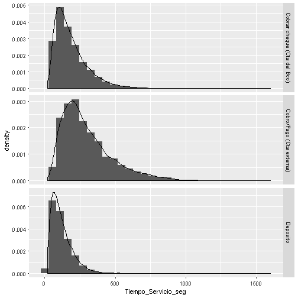

```r
ggplot(data_banco, aes(x = Tiempo_Servicio_seg)) +
  geom_histogram(aes(y = ..density..)) +
  geom_density(lwd=0.2) +
  facet_grid(Transaccion~., scales = "free_y")
```

### ggplot2

facet_wrap permite otras cosas

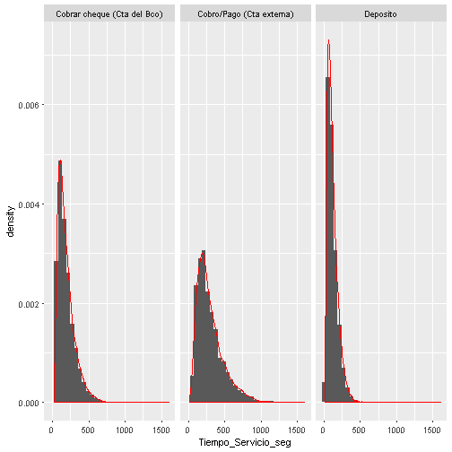

```r
ggplot(data_banco, aes(x = Tiempo_Servicio_seg)) +
  geom_histogram(aes(y = ..density..)) +
  geom_density(lwd=0.2, color= "red") +
  facet_wrap("Transaccion")
```

### ggplot2

Puedo obligar a facet_wrap a que tenga 2 filas

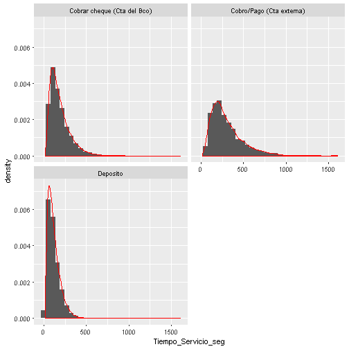

```r
ggplot(data_banco, aes(x = Tiempo_Servicio_seg)) +
  geom_histogram(aes(y = ..density..)) +
  geom_density(lwd=0.2, color= "red") +
  facet_wrap("Transaccion", nrow = 2)
```

### ggplot2

Usamos *fill* y *color* para transacción y facet_wrap para dividir por sucursal

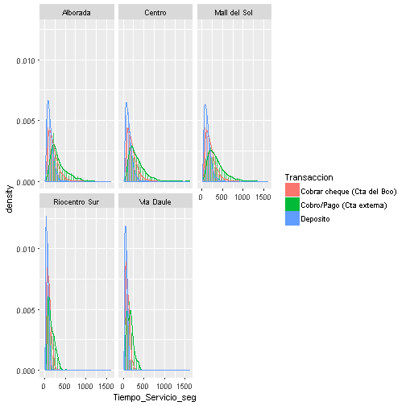

```r
ggplot(data_banco, aes(x = Tiempo_Servicio_seg)) +
  geom_histogram(aes(y = ..density.., fill= Transaccion),  position = "dodge", alpha= 0.7) +
  geom_density(aes(color= Transaccion), lwd=0.2 ) +
  facet_wrap("Sucursal")
```

### ggplot2

Agregar una distribución marginal

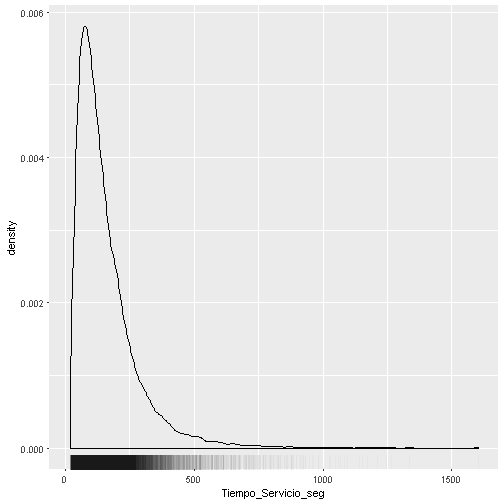

```r
ggplot(data_banco, aes(x = Tiempo_Servicio_seg)) +
  geom_density(lwd=0.2 ) +
  geom_rug(alpha=0.02)
```

### ggplot2

Agregar una línea de media

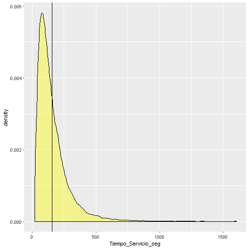

```r
ggplot(data_banco, aes(x = Tiempo_Servicio_seg)) +
  geom_density(alpha=0.4, lwd=0.2, fill= "yellow" ) +
  geom_vline(aes(xintercept = mean(Tiempo_Servicio_seg)))
```

### ggplot2

Agregar una línea de media

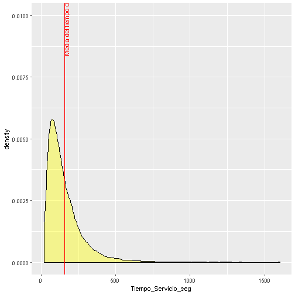

```r
ggplot(data_banco, aes(x = Tiempo_Servicio_seg)) +
  geom_density(alpha=0.4, lwd=0.2, fill= "yellow" ) +
  geom_vline(aes(xintercept = mean(Tiempo_Servicio_seg)), color= "red") +
  geom_text(aes(x=mean(Tiempo_Servicio_seg) + 10, label="Media del tiempo de servicio", y=0.01), colour="red", angle=90)
```

### ggplot2

Agregar una línea de media

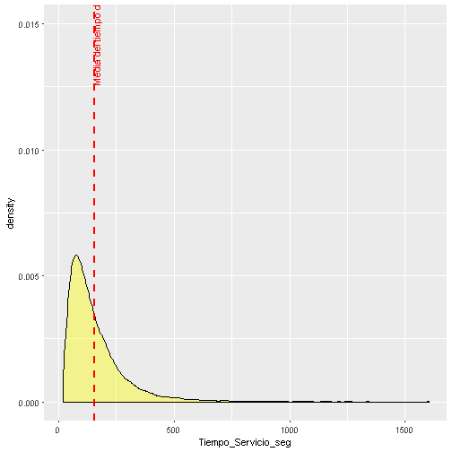

```r
ggplot(data_banco, aes(x = Tiempo_Servicio_seg)) +
  geom_density(alpha=0.4, lwd=0.2, fill= "yellow" ) +
  geom_vline(aes(xintercept = mean(Tiempo_Servicio_seg)), color= "red", linetype= "dashed", size= 1) +
  geom_text(aes(x=mean(Tiempo_Servicio_seg) + 7, label="Media del tiempo de servicio", y=0.015), colour="red", angle=90)
```

### ggplot2

Separemos la densidad por Transacción usando *fill* (No se calcula la media)

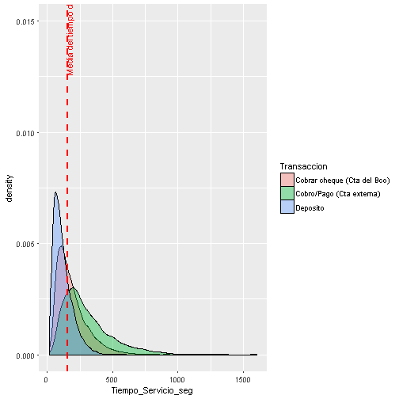

```r
ggplot(data_banco, aes(x = Tiempo_Servicio_seg, fill= Transaccion)) +
  geom_density(alpha=0.4, lwd=0.2) +
  geom_vline(aes(xintercept = mean(Tiempo_Servicio_seg)), color= "red", linetype= "dashed", size= 1) +
  geom_text(aes(x=mean(Tiempo_Servicio_seg) + 7, label="Media del tiempo de servicio", y=0.015), colour="red", angle=90)
```

### ggplot2

Se debe calcular la media aparte

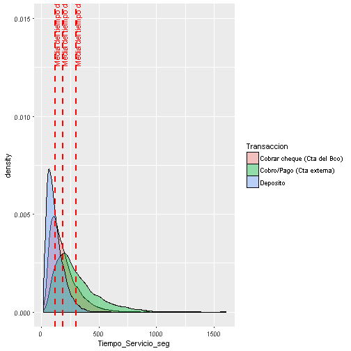

```r
df_medias <- data_banco %>% group_by(Transaccion) %>% summarise(MEDIA= mean(Tiempo_Servicio_seg, na.rm= TRUE)  )
ggplot(data_banco, aes(x = Tiempo_Servicio_seg, fill= Transaccion)) +
  geom_density(alpha=0.4, lwd=0.2) +
  geom_vline(data = df_medias, aes(xintercept = MEDIA), color= "red", linetype= "dashed", size= 1) +
  geom_text(data = df_medias, aes(x=MEDIA + 7, label="Media del tiempo de servicio", y=0.015), colour="red", angle=90)
```

### ggplot2

Para tener color por Transacción, mapeamos color dentro del aes()

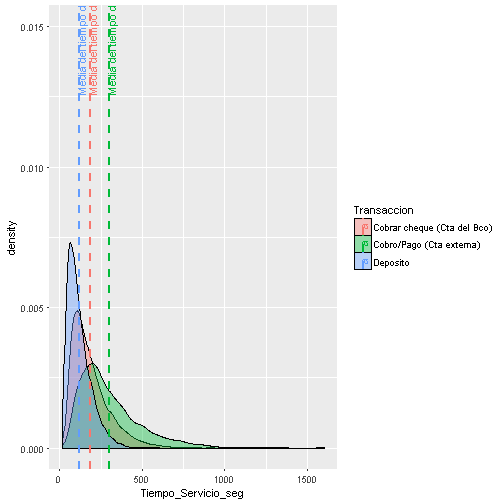

```r
df_medias <- data_banco %>% group_by(Transaccion) %>% summarise(MEDIA= mean(Tiempo_Servicio_seg, na.rm= TRUE)  )
ggplot(data_banco, aes(x = Tiempo_Servicio_seg, fill= Transaccion)) +
  geom_density(alpha=0.4, lwd=0.2) +
  geom_vline(data = df_medias, aes(xintercept = MEDIA, colour= Transaccion), linetype= "dashed", size= 1) +
  geom_text(data = df_medias, aes(x=MEDIA + 7, label="Media del tiempo de servicio", y=0.015, colour= Transaccion), , angle=90)
```

### ggplot2

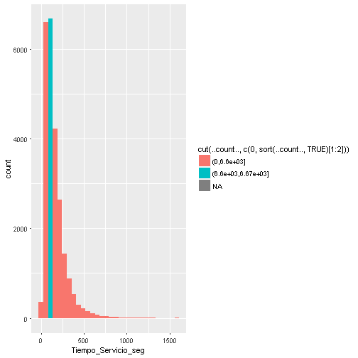

```r
ggplot(data_banco, aes(x = Tiempo_Servicio_seg)) +
  geom_histogram(aes(y    = ..count..,
                     fill = cut(..count.., c(0, sort(..count.., TRUE)[1:2]))
                                  ))
```

### ggplot2

Para entender el cut

```r
g <- ggplot(data_banco, aes(x = Tiempo_Servicio_seg)) +
  geom_histogram(aes(y    = ..count..))

cut(ggplot_build(g)$data[[1]]$count, c(0, sort(ggplot_build(g)$data[[1]]$count, TRUE)[1:2]))
```

```
 [1] (0,6.6e+03]        (0,6.6e+03]        (6.6e+03,6.67e+03]
 [4] (0,6.6e+03]        (0,6.6e+03]        (0,6.6e+03]
 [7] (0,6.6e+03]        (0,6.6e+03]        (0,6.6e+03]
[10] (0,6.6e+03]        (0,6.6e+03]        (0,6.6e+03]
[13] (0,6.6e+03]        (0,6.6e+03]        (0,6.6e+03]
[16] (0,6.6e+03]        (0,6.6e+03]        (0,6.6e+03]
[19] (0,6.6e+03]        (0,6.6e+03]        (0,6.6e+03]
[22] (0,6.6e+03]        (0,6.6e+03]        (0,6.6e+03]
[25] (0,6.6e+03]        <NA>               <NA>
[28] <NA>               <NA>               (0,6.6e+03]
Levels: (0,6.6e+03] (6.6e+03,6.67e+03]
```